# CW1 final

K.D.S.D.Amarasinghe

2025-02-04

```r
Data <- read.csv(file.choose())
Data
```

[output not shown]

[output cut: 4278 more lines]

```r
head(Data)
```

```
##       Date CO.Value
## 1 1/1/2014       34
## 2 1/2/2014       28
## 3 1/3/2014       20
## 4 1/4/2014       27
## 5 1/5/2014       25
## 6 1/6/2014       25
```

```r
library(ggplot2)
library(tidyverse)
library(dplyr)
```

# Data preprocessing

```r
colSums(is.na(Data))
```

```
##     Date CO.Value
##        0        0
```

```r
# Identify outliers using IQR method
Q1 <- quantile(Data$CO, 0.25, na.rm = TRUE)
Q3 <- quantile(Data$CO, 0.75, na.rm = TRUE)
IQR_value <- Q3 - Q1

# Define lower and upper bounds
lower_bound <- Q1 - 1.5 * IQR_value
upper_bound <- Q3 + 1.5 * IQR_value

# Compute the median value
median_value <- median(Data$CO, na.rm = TRUE)

# Replace outliers with the median value
df <- Data %>% mutate(CO.Value = ifelse(CO.Value < lower_bound | CO.Value > upper_bound, median_value, CO.Value))
```

#Aggregreate in daily data into monthly data

```r
df$Date <- as.Date(df$Date, format = "%m/%d/%Y")
df$Year <- year(df$Date)
df$Month <- month(df$Date)
df <- df %>%
  mutate(Year_Month = format(Date, "%Y-%m"))

df_monthly <- df%>%
  group_by(Year, Month, Year_Month)%>%
  summarise(CO_level = mean(CO.Value, na.rm = TRUE),.groups = "drop")
head(df_monthly)
```

```
## # A tibble: 6 × 4
##    Year Month Year_Month CO_level
##   <dbl> <dbl> <chr>         <dbl>
## 1  2014     1 2014-01       14.6
## 2  2014     2 2014-02       14.3
## 3  2014     3 2014-03       11.2
## 4  2014     4 2014-04        8.9
## 5  2014     5 2014-05        8.35
## 6  2014     6 2014-06        8.83
```

#separete monthly data into train data and test data #total count of months is 130 and train 115 months and use 15 months for test .

```r
# Define the number of training and testing observations
train_size <- 115
test_size <- 15

# Ensure the total length matches
total_length <- length(df_monthly$CO_level)
if (train_size + test_size != total_length) {
  stop("Train and test sizes do not match the total length of the dataset")
}

# Split the data
train_data <- df_monthly$CO_level[1:train_size]
test_data <- df_monthly$CO_level[(train_size + 1):total_length]

# Print the lengths to verify
cat("Train Data Length:", length(train_data), "\n")
```

```
## Train Data Length: 115
```

```r
cat("Test Data Length:", length(test_data), "\n")
```

```
## Test Data Length: 15
```

```r
cat("Total Data Length:", length(df_monthly$CO_level), "\n")
```

```
## Total Data Length: 130
```

# Exploratory Data Analysis(EDA)

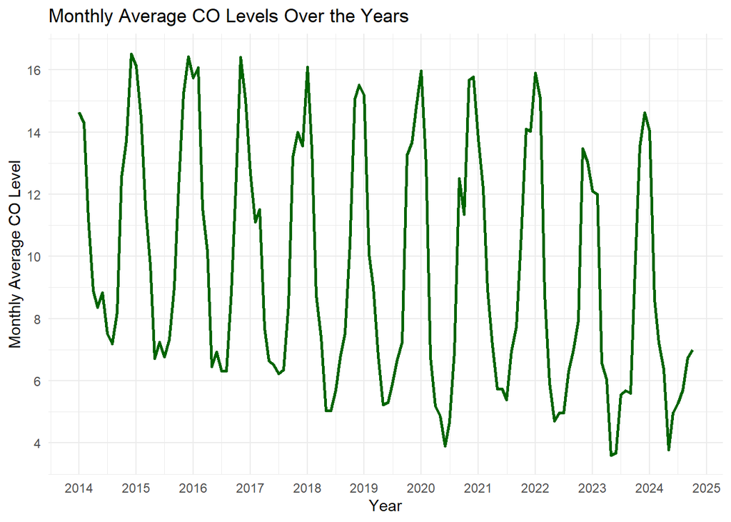

```r
ggplot(df_monthly, aes(x = as.Date(paste0(Year_Month, "-01")), y = CO_level)) +
  geom_line(color = "darkgreen", size = 1.0) +
  labs(title = "Monthly Average CO Levels Over the Years", x = "Year", y = "Monthly Average CO Level") +
  scale_x_date(date_breaks = "1 year", date_labels = "%Y") +  # Show every year
  scale_y_continuous(breaks = seq(0, max(df_monthly$CO_level, na.rm = TRUE), by = 2)) +
  theme_minimal()
```

```r
#convert train data into time series
ts_train <- ts(train_data, frequency = 12, start = c(2014,1))  # Frequency = 12 for monthly data
```

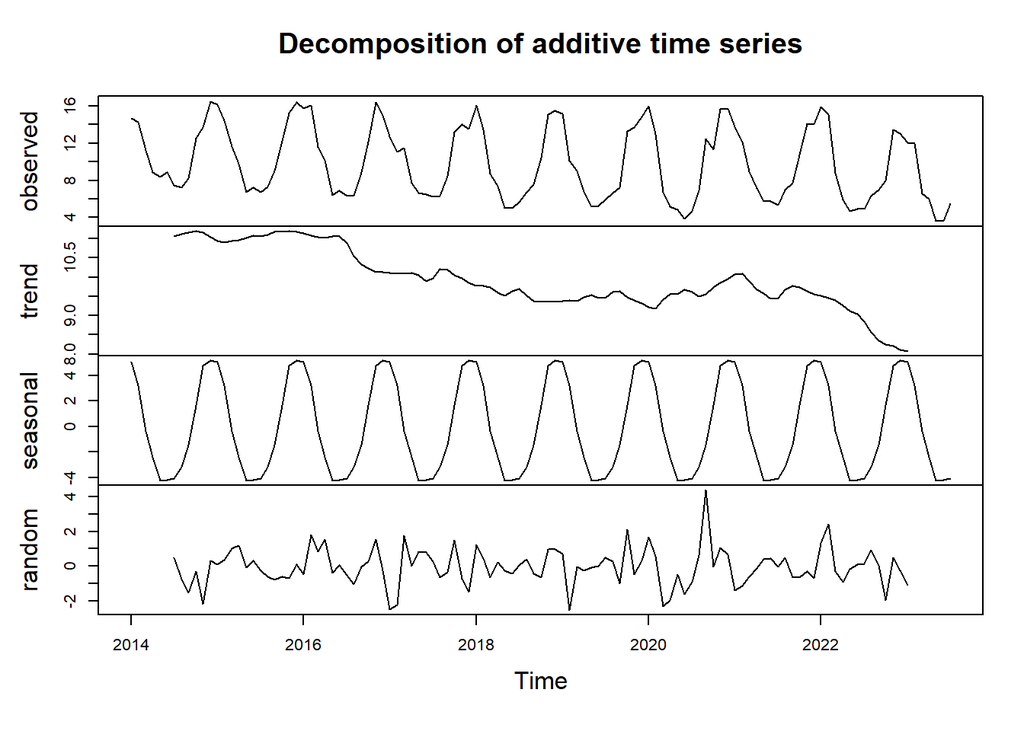

```r
# Decompose the time series using classical decomposition
decomp <- decompose(ts_train)

# Plot the decomposition components
plot(decomp)
```

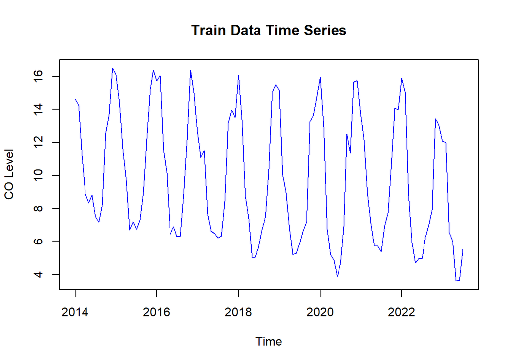

```r
plot(ts_train, main = "Train Data Time Series",
     xlab = "Time", ylab = "CO Level", col = "blue", type = "l")
```

```r
# Compute basic statistical properties
mean_CO <- mean(ts_train, na.rm = TRUE)
print(mean_CO)
```

```
## [1] 9.836136
```

```r
var_CO <- var(ts_train, na.rm = TRUE)
print(var_CO)
```

```
## [1] 14.81226
```

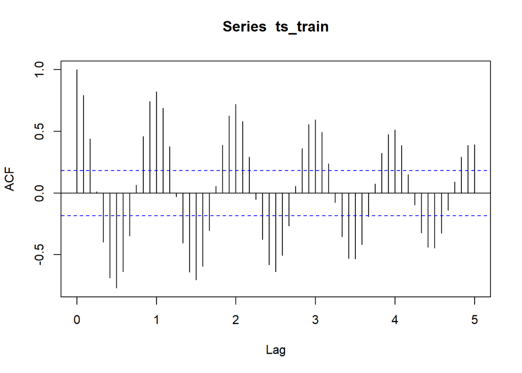

```r
# Compute and plot autocorrelation
autocorr_CO <- acf(ts_train,lag.max = 60, plot = TRUE)
```

# Stationarity and Transformation

```r
library(tseries)
adf.test(ts_train)
```

```
##
##  Augmented Dickey-Fuller Test
##
## data:  ts_train
## Dickey-Fuller = -10.36, Lag order = 4, p-value = 0.01
## alternative hypothesis: stationary
```

#from the results of ADF test , p-value < 0.05 , so we don’t need to do differencing to transformation

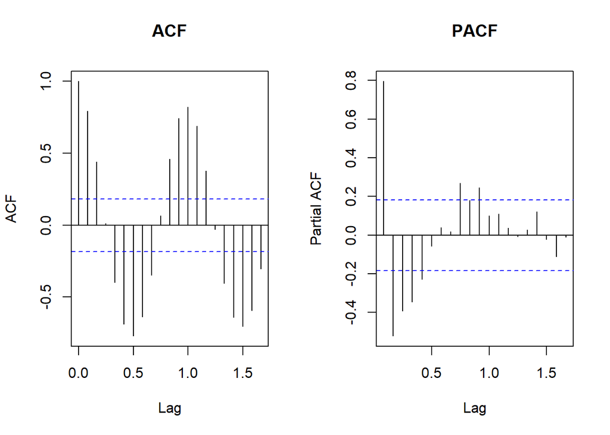

```r
par(mfrow = c(1, 2))
acf(ts_train, main = "ACF")
pacf(ts_train, main = "PACF")
```

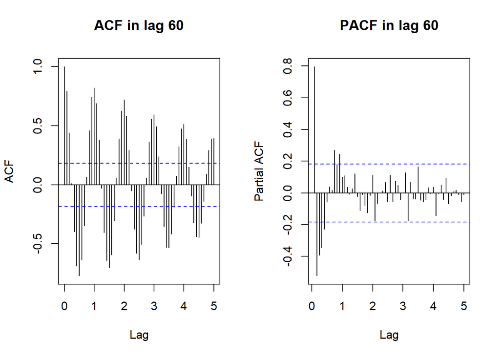

```r
par(mfrow = c(1, 2))
acf(ts_train, main = "ACF in lag 60",lag.max = 60)
pacf(ts_train, main = "PACF in lag 60",lag.max = 60)
```

#from this ACF and PACF plots we can see seasonality is continue over the time , so we can apply Seasonal ARIMA (SARIMA)model. #we can apply seasonal differncing to remove seasonality in time series #apply seasonal differencing 1

```r
ts_diff1 <- diff(ts_train, lag = 12)
```

#check seasonality is removed

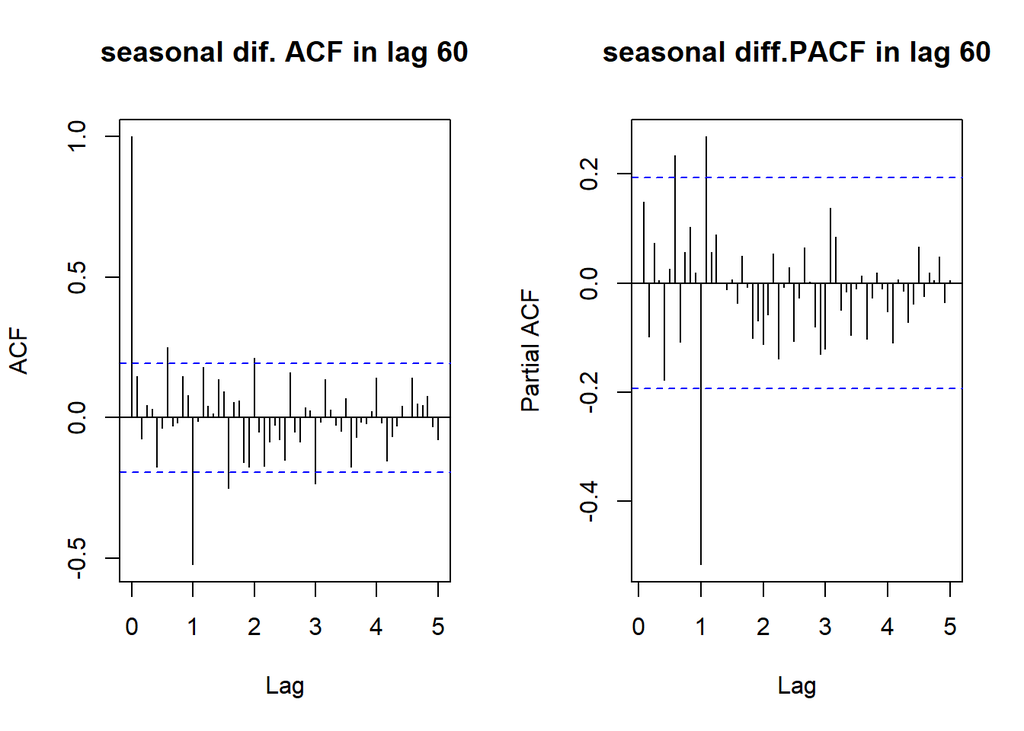

```r
par(mfrow = c(1, 2))
acf(ts_diff1, main = "seasonal dif. ACF in lag 60",lag.max = 60)
pacf(ts_diff1, main = "seasonal diff.PACF in lag 60",lag.max = 60)
```

#from the seasonal differenced 1 applyed acf plot we can see seasonality is removed , so we don’t need to go for a seasonal difference 2.

#apply SARIMA model #auto arima(SARIMA) model was applyed to the non-seasonal differenced train data set .

```r
library(forecast)
# Fit the best SARIMA model to the train data
sarima_model <- auto.arima(ts_train)

# Print the ARIMA model summary
summary(sarima_model)
```

```
## Series: ts_train
## ARIMA(0,0,1)(0,1,1)[12] with drift
##
## Coefficients:
##          ma1     sma1    drift
##       0.2537  -0.8047  -0.0241
## s.e.  0.0964   0.1275   0.0047
##
## sigma^2 = 1.564:  log likelihood = -173.85
## AIC=355.71   AICc=356.12   BIC=366.25
##
## Training set error measures:
##                      ME     RMSE      MAE       MPE     MAPE      MASE
## Training set 0.01063428 1.166196 0.833214 -1.565554 9.177578 0.6554392
##                     ACF1
## Training set 0.001002359
```

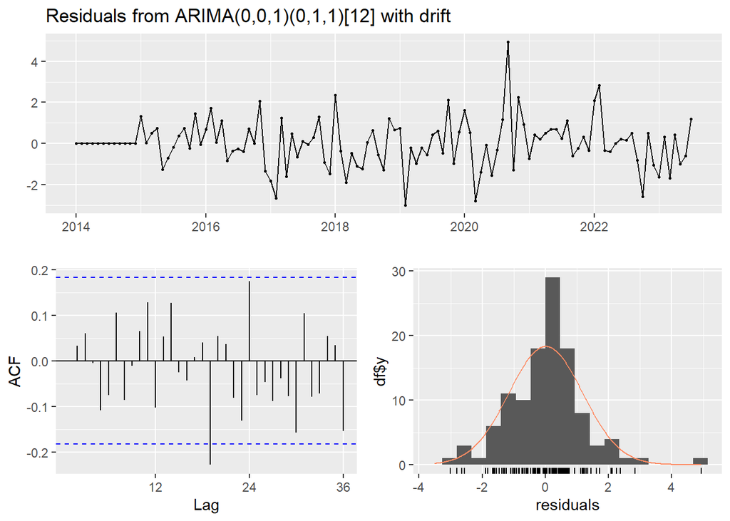

```
##
##  Ljung-Box test
##
## data:  Residuals from ARIMA(0,0,1)(0,1,1)[12] with drift
## Q* = 23.509, df = 21, p-value = 0.3174
##
## Model df: 2.   Total lags used: 23
```

```r
checkresiduals(sarima_model)
```

#apply Exponential smoothing

```r
ets_model <- ets(ts_train)
summary(ets_model)
```

```
## ETS(M,A,A)
##
## Call:
## ets(y = ts_train)
##
##   Smoothing parameters:
##     alpha = 0.0164
##     beta  = 1e-04
##     gamma = 5e-04
##
##   Initial states:
##     l = 11.293
##     b = -0.0244
##     s = 5.213 4.7795 1.6398 -0.9839 -3.1892 -3.9909
##            -4.1564 -4.2934 -2.408 -0.3628 3.2035 4.5489
##
##   sigma:  0.1318
##
##      AIC     AICc      BIC
## 604.8303 611.1396 651.4941
##
## Training set error measures:
##                       ME     RMSE       MAE       MPE     MAPE      MASE
## Training set 0.009535305 1.147001 0.8400247 -1.307281 9.187186 0.6607967
##                   ACF1
## Training set 0.2394559
```

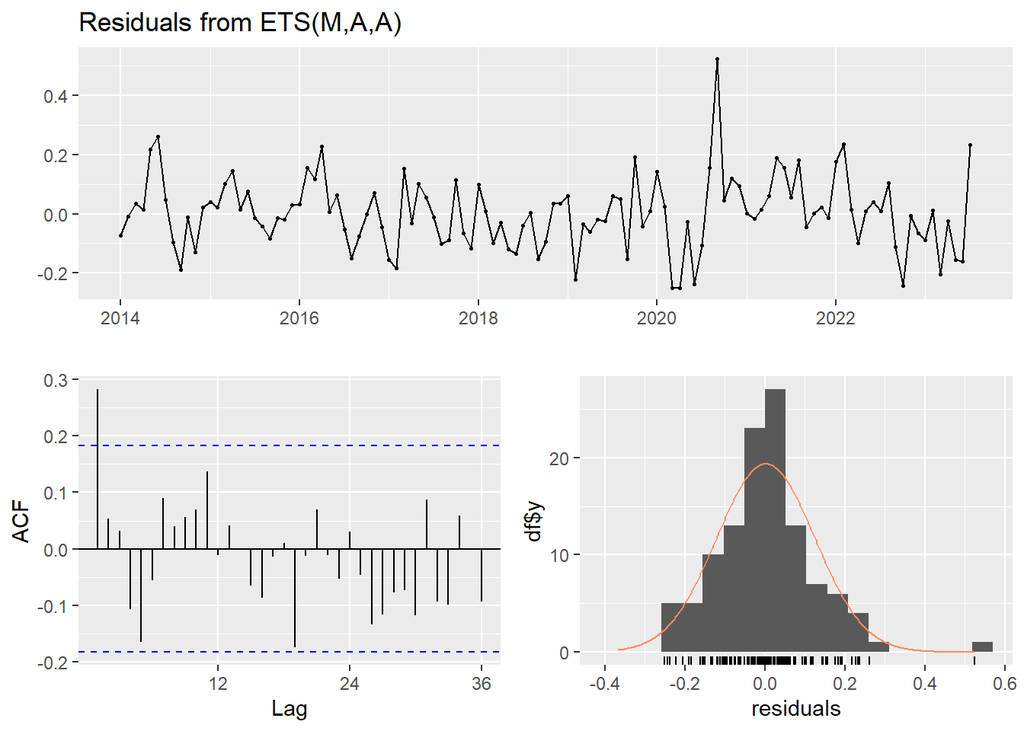

```
##
##  Ljung-Box test
##
## data:  Residuals from ETS(M,A,A)
## Q* = 26.902, df = 23, p-value = 0.2602
##
## Model df: 0.   Total lags used: 23
```

```r
checkresiduals(ets_model)
```

#based on the comparison of auto ARIMA(SARIMA)test and ETS model - the SARIMA model is the beter fit model for the our time series data.because, SARIMA model has lower AIC ,BIC values (AIC=355.71 BIC=366.25)comparing to ETS model AIC and BIC results(AIC=604.8303 BIC= 651.4941) #from the results of Ljung-Box test check the resuduals of our SARIMA model are uncorrelated or not, from the results of SARIMA test P-value is 0.3174 it is greater than 0.05 and we fail to reject null hypothesis (H0),it means the residuals of SARIMA model don’t show autocorrelation and SARIMA model has captured the patterns in the data.

```r
#cross validation to select the best forecasting model

#each model was fit to the training data
sarima_forecast <- forecast(sarima_model, h = length(test_data))
ets_forecast <- forecast(ets_model, h = length(test_data))

#calculating the accuracy metrics
sarima_accuracy <- accuracy(sarima_forecast, test_data)
ets_accuracy <- accuracy(ets_forecast, test_data)

print(sarima_accuracy)
```

```
##                       ME     RMSE       MAE       MPE      MAPE      MASE
## Training set  0.01063428 1.166196 0.8332140 -1.565554  9.177578 0.4671883
## Test set     -0.26312773 1.257493 0.9073001 -3.996575 12.702126 0.5087288
##                     ACF1
## Training set 0.001002359
## Test set              NA
```

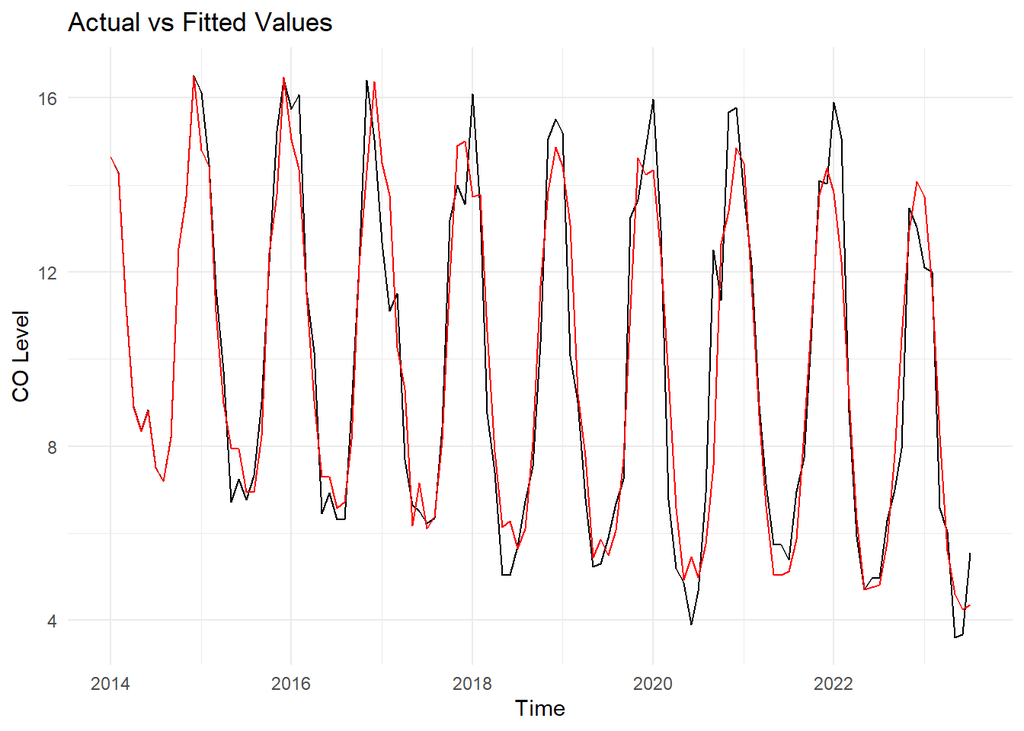

```r
# Generate fitted values for the training data
fitted_values <- fitted(sarima_model)

# Create a plot comparing actual vs fitted values
autoplot(ts_train) +
  geom_line(aes(y = fitted_values), color = "red") +
  labs(title = "Actual vs Fitted Values",
       x = "Time", y = "CO Level") +
  theme_minimal()
```

#from this actual vs. fitted graph the black line shows the actual CO values and red line represent the fitted values from the above applyed sarima model.the fitted values closely go with actual values, while capturing the seasonal pattern and downword trend over the given time period.their is some small deviations where fitted values slightly overestimated and underestimated the actual CO value , but overall we can see the model was fitted well.

```r
# finding forecast accuracy using metrics MAE, RMSE and MAPE
sarima_accuracy <- accuracy(sarima_forecast, test_data)

print(sarima_accuracy)
```

```
##                       ME     RMSE       MAE       MPE      MAPE      MASE
## Training set  0.01063428 1.166196 0.8332140 -1.565554  9.177578 0.4671883
## Test set     -0.26312773 1.257493 0.9073001 -3.996575 12.702126 0.5087288
##                     ACF1
## Training set 0.001002359
## Test set              NA
```

#from this code we can see the accuracy metrics for the training set and test set. training set metrics shows how well the model fits the training data. test set metrics shows how well the model forecasts match the actual test data to see how well it performed in predicting. so for forecast accuracy we use test set metrics.

# Forecasting

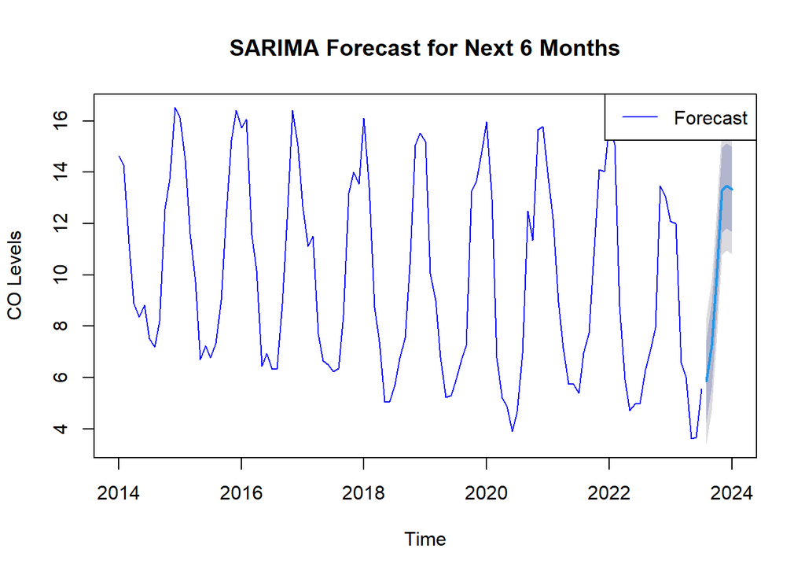

```r
# generating forecasts for the next 6 months
sarima_forecast_6months <- forecast(sarima_model, h = 6)

# plotting the 12 month forecast
plot(sarima_forecast_6months, main = "SARIMA Forecast for Next 6 Months",
     xlab = "Time", ylab = "CO Levels", col = "blue")

legend("topright", legend = "Forecast", col = "blue", lty = 1, cex = 1.0)
```